# Example R Analysis: Data Visualization

Demonstrating R Markdown with executable code, plots, and cross-references

By Benjamin Peeters

# Example R Analysis: Data Visualization

Demonstrating R Markdown with executable code, plots, and cross-references

Author

Benjamin Peeters

## Introduction

This is an example R Markdown document that demonstrates the integration of:

- Executable R code
- Data visualization
- Mathematical equations with cross-references
- Interactive analysis

## Mathematical Foundation

The linear regression model is defined as:

$$y_i = \beta_0 + \beta_1 x_i + \epsilon_i \tag{1}$$

where $\epsilon_i \sim N(0, \sigma^2)$ represents the error term.

The coefficient of determination is:

$$R^2 = 1 - \frac{\sum_{i=1}^{n}(y_i - \hat{y}_i)^2}{\sum_{i=1}^{n}(y_i - \bar{y})^2} \tag{2}$$

## Data Analysis

Let’s demonstrate with a simple analysis using R:

```r
# Generate sample data
set.seed(42)
n <- 100
x <- seq(0, 10, length.out = n)
y <- 2 + 3 * x + rnorm(n, sd = 2)
data <- data.frame(x = x, y = y)

# Summary statistics
summary(data)
```

```
       x              y
 Min.   : 0.0   Min.   : 1.174
 1st Qu.: 2.5   1st Qu.: 9.316
 Median : 5.0   Median :17.149
 Mean   : 5.0   Mean   :17.065
 3rd Qu.: 7.5   3rd Qu.:24.397
 Max.   :10.0   Max.   :33.306
```

### Regression Model

We fit the linear model described in Equation 1:

```r
# Fit linear regression
model <- lm(y ~ x, data = data)
summary(model)
```

```
Call:
lm(formula = y ~ x, data = data)

Residuals:
    Min      1Q  Median      3Q     Max
-6.0389 -1.3237  0.1618  1.3054  4.4527

Coefficients:
            Estimate Std. Error t value Pr(>|t|)
(Intercept)  2.13643    0.41546   5.142 1.39e-06 ***
x            2.98572    0.07178  41.596  < 2e-16 ***
---
Signif. codes:  0 '***' 0.001 '**' 0.01 '*' 0.05 '.' 0.1 ' ' 1

Residual standard error: 2.093 on 98 degrees of freedom
Multiple R-squared:  0.9464,    Adjusted R-squared:  0.9459
F-statistic:  1730 on 1 and 98 DF,  p-value: < 2.2e-16
```

The $R^2$ value from Equation 2 is 0.946.

### Visualization

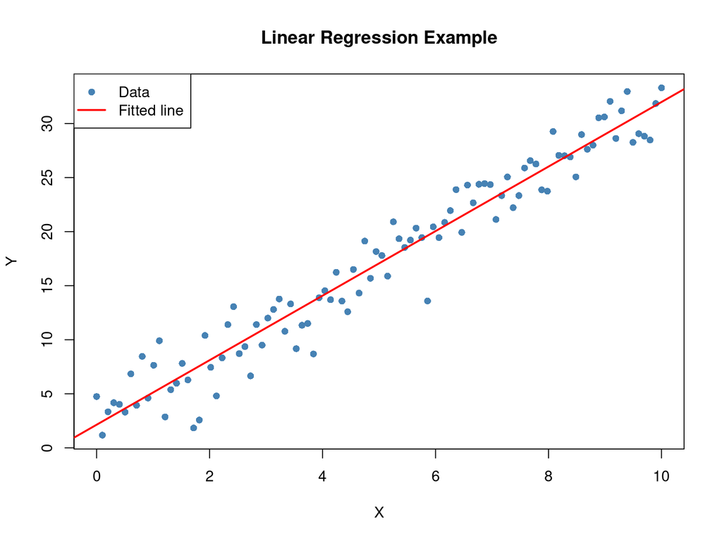

```r
# Create scatter plot with regression line
plot(data$x, data$y,
     pch = 16, col = "steelblue",
     xlab = "X", ylab = "Y",
     main = "Linear Regression Example")
abline(model, col = "red", lwd = 2)
legend("topleft",
       legend = c("Data", "Fitted line"),
       col = c("steelblue", "red"),
       pch = c(16, NA),
       lty = c(NA, 1),
       lwd = c(NA, 2))
```

## Results

As shown in Section 3, the linear relationship between $x$ and $y$ is well-captured by the model in Equation 1.

Key findings:

1. The estimated slope is approximately 3
2. The intercept is close to 2
3. The model explains most of the variance in the data

## Conclusion

This document demonstrates the capability to:

- Execute R code and display results
- Generate plots and visualizations
- Use equation cross-references (Equation 1, Equation 2)
- Reference sections (Section 1, Section 2, Section 3)